# Quality Control RNAseq

## Quality Control RNAseq

### Sequencing quality

The sequencing quality of the run was good, and the read distribution over the libraries was good. See tables the SAV quality tables:

| Desc | Value |
| --- | --- |
| Machine | HWI-ST558 |
| Run Folder | 141010-SN558-0265-AC49HNACXX |
| Chip ID | unknown |

| Lane | Lane Yield (kbases) | Clusters (raw) | Clusters (PF) | First Cycle Int (PF) | \% intensity after 20 cycles (PF) | \% PF Clusters |
| --- | --- | --- | --- | --- | --- | --- |
| 1 | 9650991 | 2201886 \( \pm \) 330864 | 1971199 \( \pm \) 243511 | 1131 \( \pm \) 126 | 79.50 \( \pm \) 1.41 | 89.90 \( \pm \) 3.11 |
| 2 | 8901946 | 2826947 \( \pm \) 152352 | 1856893 \( \pm \) 491548 | 949 \( \pm \) 210 | 75.97 \( \pm \) 14.31 | 66.08 \( \pm \) 18.49 |
| 3 | 8314272 | 1836538 \( \pm \) 270076 | 1698176 \( \pm \) 215295 | 1002 \( \pm \) 113 | 79.78 \( \pm \) 5.05 | 92.74 \( \pm \) 2.04 |
| 4 | 10036281 | 2356506 \( \pm \) 334192 | 2049894 \( \pm \) 260168 | 1282 \( \pm \) 189 | 66.48 \( \pm \) 6.95 | 87.59 \( \pm \) 7.99 |
| 5 | 10837353 | 2652785 \( \pm \) 175894 | 2213511 \( \pm \) 84079 | 1030 \( \pm \) 105 | 78.68 \( \pm \) 2.15 | 83.66 \( \pm \) 3.96 |
| 6 | 9773962 | 2222935 \( \pm \) 439671 | 1996315 \( \pm \) 314381 | 1096 \( \pm \) 110 | 76.58 \( \pm \) 1.84 | 90.49 \( \pm \) 3.65 |
| 7 | 10894107 | 2540112 \( \pm \) 527322 | 2225103 \( \pm \) 341898 | 1069 \( \pm \) 107 | 77.01 \( \pm \) 1.55 | 88.62 \( \pm \) 5.39 |
| 8 | 10914079 | 2536972 \( \pm \) 501254 | 2229182 \( \pm \) 326316 | 1069 \( \pm \) 101 | 77.08 \( \pm \) 1.52 | 88.76 \( \pm \) 4.86 |

| Lane | Clusters(tile \( \mu \),raw) | \% Phas | \% Prephas | \% Retained(raw) | Cyc2-4 \( \mu \) Int(raw,PF) | Cyc2-10 \( \mu \) \% Loss(filt,PF) | Cyc10-20 \( \mu \) \% Loss(filt,PF) |
| --- | --- | --- | --- | --- | --- | --- | --- |
| 1 | 2201886.01 | 0.2412 | 0.0944 | 89.90 | 1056.01 \( \pm \) 111.56 | 1.49 \( \pm \) 0.19 | 0.81 \( \pm \) 0.08 |
| 2 | 2826947.72 | 0.2412 | 0.0944 | 66.08 | 916.64 \( \pm \) 107.86 | -4.29 \( \pm \) 17.52 | 0.92 \( \pm \) 0.19 |
| 3 | 1836538.88 | 0.2412 | 0.0944 | 92.74 | 937.78 \( \pm \) 100.02 | 0.63 \( \pm \) 0.16 | 0.77 \( \pm \) 0.16 |
| 4 | 2356506.43 | 0.2412 | 0.0944 | 87.59 | 996.38 \( \pm \) 105.28 | 0.85 \( \pm \) 0.11 | 0.75 \( \pm \) 0.12 |
| 5 | 2652785.95 | 0.2412 | 0.0944 | 83.66 | 959.75 \( \pm \) 104.07 | 0.43 \( \pm \) 0.10 | 0.87 \( \pm \) 0.14 |
| 6 | 2222935.44 | 0.2412 | 0.0944 | 90.49 | 991.34 \( \pm \) 104.88 | -0.01 \( \pm \) 0.13 | 1.32 \( \pm \) 0.10 |
| 7 | 2540112.88 | 0.2412 | 0.0944 | 88.62 | 976.06 \( \pm \) 105.42 | 0.25 \( \pm \) 0.18 | 0.81 \( \pm \) 0.12 |
| 8 | 2536972.71 | 0.2412 | 0.0944 | 88.76 | 977.67 \( \pm \) 98.56 | 0.25 \( \pm \) 0.09 | 0.82 \( \pm \) 0.10 |

### Mapping

Mapping was done using STAR. The program version and genome assembly are described in the following table. The following parameters were used to get only uniquely mapping reads:

|  | parms |
| --- | --- |
| version | STAR_2.3.1z13_r470 |
| runMode | alignReads |
| limitGenomeGenerateRAM | 31000000000 |
| limitIObufferSize | 150000000 |
| genomeDir | /fsimb/groups/imb-bi…tar_genomes/mm9/ |
| runThreadN | 8 |
| outFilterMismatchNmax | 2 |
| outFilterMultimapNmax | 10 |
| genomeLoad | NoSharedMemory |
| alignIntronMin | 21 |
| outStd | SAM |
| outSAMattributes | Standard |
| outSJfilterReads | Unique |
| sjdbGTFfile | /fsimb/groups/imb-bi…/Genes/genes.gtf |
| readFilesCommand | zcat |
| versionGenome | 20101 |
| genomeFastaFiles | mm9.fa |
| genomeSAindexNbases | 14 |
| genomeChrBinNbits | 18 |
| genomeSAsparseD | 1 |
| sjdbOverhang | 100 |
| sjdbFileChrStartEnd | - |

The mapping statistics show the total number of reads delivered to the aligner, the number of uniquely mapped reads, and the number of reads discarded because of mapping to multiple positions or not mapping at all to the reference genome.

|  | input_reads | uniq_mapped | multimapped | unmapped |
| --- | --- | --- | --- | --- |
| 12_mESCs_shMed12_rep_1 | 4839552 | 2927429 (60.49%) | 1912123 (39.51%) | 0% |
| 19_mESCs_shNMC_rep_2 | 5678147 | 3582292 (63.09%) | 2095855 (36.91%) | 0% |
| 21_mESCs_shMed12_rep_2 | 4321806 | 2656616 (61.47%) | 1665190 (38.53%) | 0% |
| 28_mESCs_shNMC_rep_1 | 5135863 | 3284015 (63.94%) | 1851848 (36.06%) | 0% |
| 37_mESCs_shNMC_rep_3 | 4295755 | 2744295 (63.88%) | 1551460 (36.12%) | 0% |
| 39_mESCs_shMed12_rep_3 | 5464407 | 3386132 (61.97%) | 2078275 (38.03%) | 0% |

### Raw reads qualities, sequence bias and duplication

[output not shown]

### PCR duplication assessment

Measuring the fraction of duplicated reads is a common quality control step for NGS data sets, which can hint towards too low library complexity due to too many PCR cycles during library preparation or other problems in the sequencing workflow. However in RNA-Seq duplicate reads arise naturally due to highly expressed genes, which renders the overall read duplication rate useless.

[output not shown]

### RNA types

[output not shown]

### Gene body coverage

[output not shown]

### Batch effect

The MDS plot shows the sample relations based on multidimensional scaling (MDS). Distances in the plot can be interpreted in terms of leading log2 fold change. Overall, we see sample replicates that show little distances within them, while groups show higher distance between them. The ratio between/within groups distances is high which means there is no batch effect (or technical variation) if the experiment was well randomized:

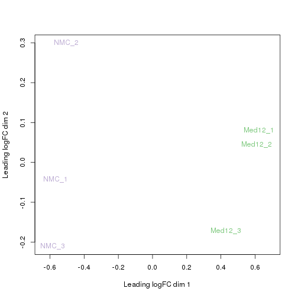

Clustering the samples based on the distance calculated on the expression levels of the 50 most variable genes, one can have an idea which samples have similar gene expression profile. This, together with the MDS plot, enables us to detect if the replicates behave similar in terms of expression and spot batches of samples related by other characteristics rather than condition:

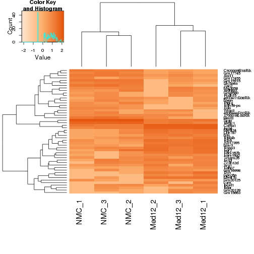

Finally, sample to sample correlation based on the distance calculated on the expression profile gives us a measure of sample similarity:

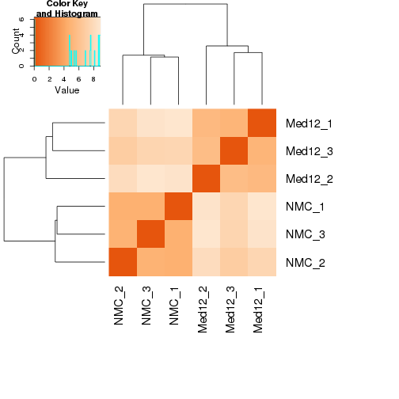

## Differential Expression Analysis

### Med12vsNMC

There are 329 genes highlighted in the MA plot with corrected pvalue (Benjamini and Hochberg, FDR) < 0.01

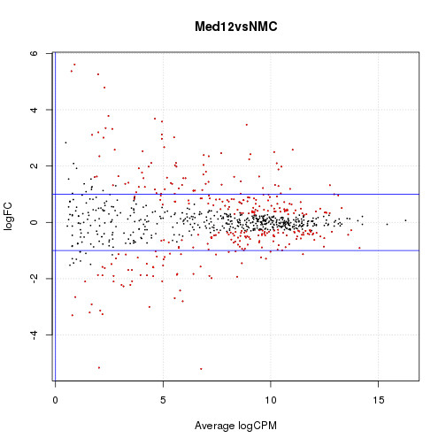

The table contains the top 25 differentially expressed genes in terms of fold change and Pvalue:

|  | logFC | logCPM | LR | PValue | FDR |
| --- | --- | --- | --- | --- | --- |
| Gprc6a | 5.61 | 0.89 | 20.48 | 0 | 0 |
| Dcn | 5.26 | 1.98 | 36.16 | 0 | 0 |
| Srgn | -5.20 | 6.77 | 412.31 | 0 | 0 |
| Tac2 | -5.16 | 2.02 | 42.05 | 0 | 0 |
| Mettl7b | 4.79 | 2.28 | 55.60 | 0 | 0 |
| Nav3 | 3.78 | 2.46 | 50.57 | 0 | 0 |
| Eya4 | 3.68 | 4.62 | 167.49 | 0 | 0 |
| Col6a1 | 3.58 | 4.95 | 204.39 | 0 | 0 |
| Tmcc3 | 3.47 | 8.88 | 621.95 | 0 | 0 |
| AI317395 | 3.35 | 2.33 | 36.43 | 0 | 0 |
| Rfx6 | 3.32 | 2.64 | 42.40 | 0 | 0 |
| Best3 | -3.26 | 2.18 | 25.64 | 0 | 0 |
| Fam162b | 3.20 | 1.99 | 28.23 | 0 | 0 |
| Slc5a4a | -3.20 | 1.59 | 19.73 | 0 | 0 |
| Gm15915 | -3.13 | 2.08 | 30.81 | 0 | 0 |
| Frk | 3.12 | 4.94 | 107.04 | 0 | 0 |
| Nts | 3.11 | 1.70 | 22.63 | 0 | 0 |
| Syt1 | 3.02 | 5.51 | 150.38 | 0 | 0 |
| Mettl24 | 3.01 | 2.23 | 31.42 | 0 | 0 |
| Hkdc1 | -3.00 | 4.36 | 102.84 | 0 | 0 |
| Tmem200a | 2.97 | 4.94 | 95.01 | 0 | 0 |
| C920009B18Rik | -2.91 | 1.68 | 20.83 | 0 | 0 |
| Hal | -2.80 | 5.91 | 202.23 | 0 | 0 |
| Cdh23 | -2.69 | 5.54 | 123.34 | 0 | 0 |
| Rgs17 | 2.67 | 5.05 | 54.15 | 0 | 0 |